# L04 ggplot II

Data Visualization (STAT 302)

April 11, 2019

# Overview

The goal of this lab is to continue the process of unlocking the power of `ggplot2` through constructing and experimenting with a few basic plots.

# Datasets

We’ll be using data from the `blue_jays.rda`, `tech_stocks.rda`, `corruption.rda`, and `cdc.txt` datasets which are already in the `/data` subdirectory in our **data_vis_labs** project.

```r
# Load package(s)
library(tidyverse)
library(ggrepel)
# Load datasets
load("data/blue_jays.rda")
load("data/tech_stocks.rda")
load("data/corruption.rda")
# Read in the cdc dataset
cdc <- read_delim(file = "data/cdc.txt", delim = "|") %>%
  mutate(genhlth = factor(genhlth,
    levels = c("excellent", "very good", "good", "fair", "poor")
  ))
```

# Exercises

Complete the following exercises.

### Exercise 1

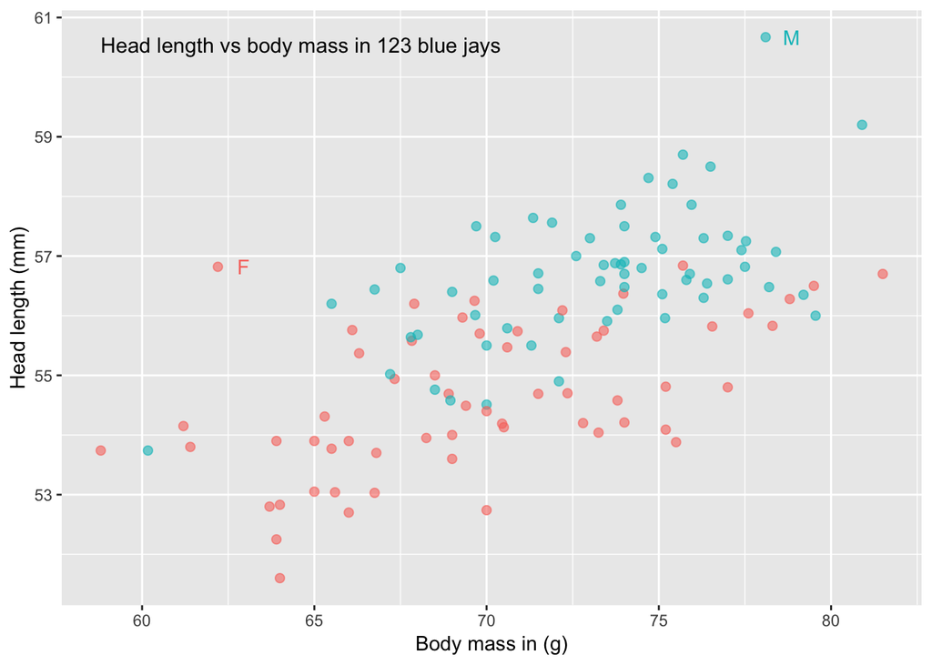

```r
yrng <- blue_jays %>% pull(Head) %>% range()
xrng <- blue_jays %>% pull(Mass) %>% range()
caption <- "Head length vs body mass in 123 blue jays"

blue_jays_text <- blue_jays %>%
  slice(8, 26)

blue_jays %>%
  ggplot(aes(Mass, Head)) +
    geom_point(aes(color = KnownSex),size = 2, alpha = 0.6, show.legend = FALSE) +
    geom_text(data = blue_jays_text, aes(label = KnownSex, color = KnownSex), nudge_x = 0.75, show.legend = FALSE) +
    xlab("Body mass in (g)") +
    ylab("Head length (mm)") +
    annotate(geom = "text", x = xrng[1], y = yrng[2], label = caption,
             hjust = 0, vjust = 1, size = 4)
```

### Exercise 2

Using `tech_stocks` dataset, recreate the following graphics as precisely as possible. *Hint:* Used `close`.

##### Plot 1

```r
last_point <- tech_stocks %>%
  filter(date == "2017-06-02")
```

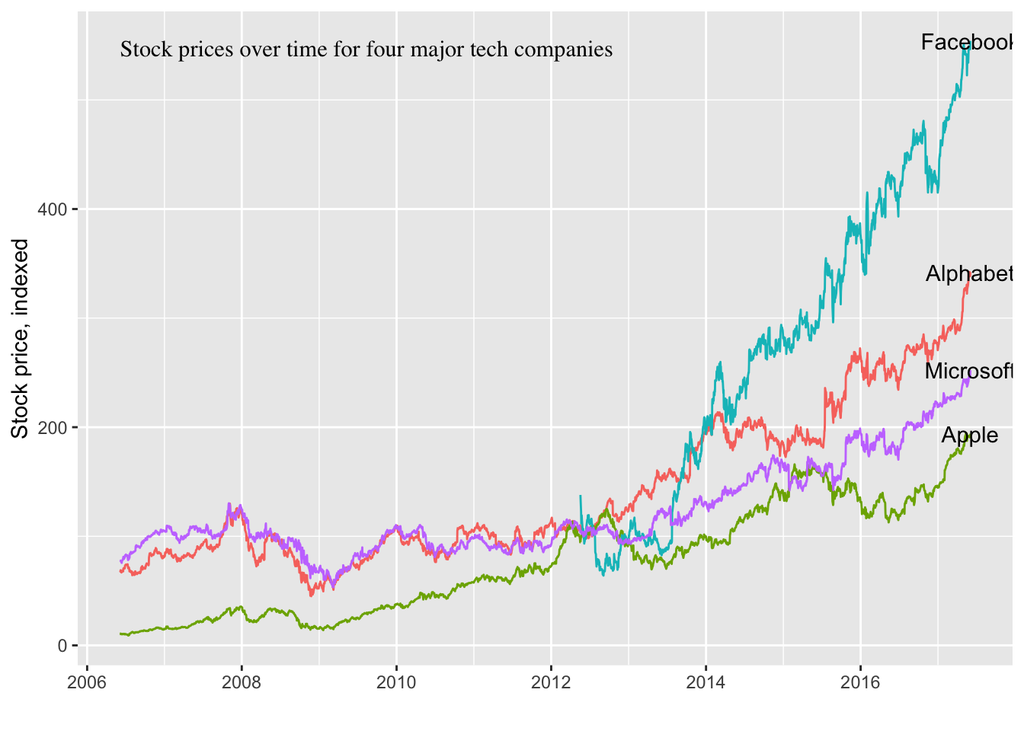

```r
yrng <- tech_stocks %>% pull(price_indexed) %>% range()
xrng <- tech_stocks %>% pull(date) %>% range()
caption <- "Stock prices over time for four major tech companies"

tech_stocks %>%
  ggplot(aes(x = date, y = price_indexed)) +
  geom_line(aes(color = company), show.legend = FALSE) +
  geom_text(data = last_point, aes(label = company), show.legend = FALSE) +
  ylab("Stock price, indexed") +
  xlab("") +
  annotate(geom = "text", x = xrng[1], y = yrng[2], label = caption, family = "serif", hjust = 0, vjust = 1, size = 4)
```

##### Plot 2

*Hints:*

- Package `ggrepel`
- `box.padding` is 0.6
- Minimum segment lent is 0
- Horizontal justification is to the right

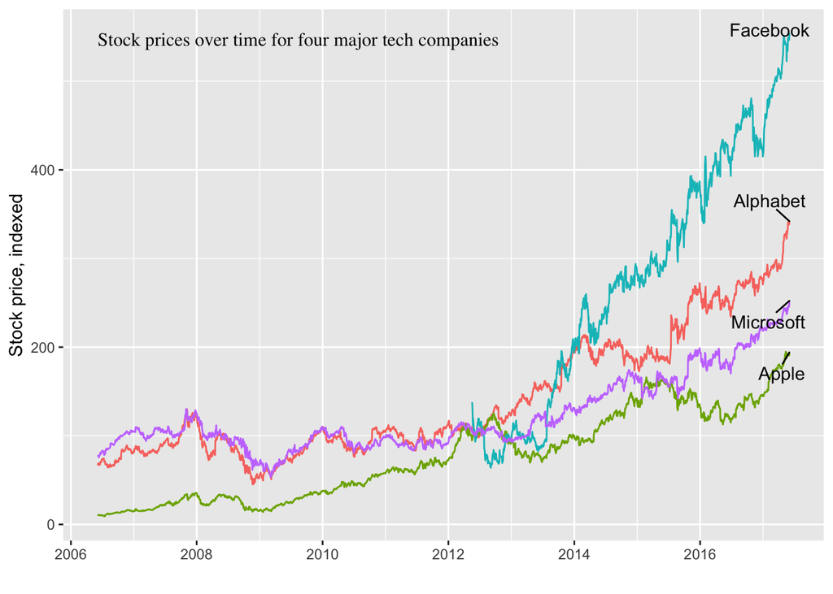

```r
set.seed(9876)
tech_stocks %>%
  ggplot(aes(x = date, y = price_indexed, label = company)) +
  geom_line(aes(color = company), show.legend = FALSE) +
  geom_text_repel(data = last_point, show.legend = FALSE,
                  box.padding = 0.6,
                  min.segment.length = 0,
                  hjust = 1) +
  ylab("Stock price, indexed") +
  xlab("") +
  annotate(geom = "text", x = xrng[1], y = yrng[2], label = caption, family = "serif", hjust = 0, vjust = 1, size = 4)
```

### Exercise 3

Using `corruption.rda` dataset, recreate the following graphic as precisely as possible.

*Hints:*

- Transparency is 0.6
- Only use 2015 data
- Color used is `grey60`
- Package `ggrepel`
- `box.padding` is 0.6
- Minimum segment lent is 0

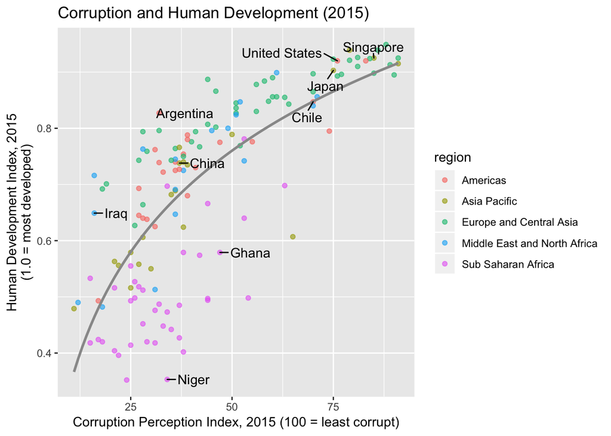

```r
corruption_plot <- corruption %>%
  filter(year == 2015) %>%
  na.omit()

set.seed(9876)

countries <- corruption_plot %>%
  slice(7, 17, 19, 23, 60, 69, 82, 87, 141)

corruption_plot %>%
  ggplot(aes(cpi, hdi, label = country)) +
    geom_point(aes(color = region), alpha = 0.6) +
    geom_smooth(method = lm, formula = "y ~ log(x)", se = FALSE, color = "grey60") +
    geom_text_repel(data = countries, show.legend = FALSE,
                  box.padding = 0.6,
                  min.segment.length = 0,
                  hjust = "right") +
    labs(x = "Corruption Perception Index, 2015 (100 = least corrupt)",
         y = "Human Development Index, 2015\n(1.0 = most developed)",
         title = "Corruption and Human Development (2015)")
```

### Exercise 4

Using `cdc` dataset, recreate the described graphic as precisely as possible.

Using Bilbo Baggins’ responses below to the CDC BRSFF questions, add Bilbo’s data point as a solid red circle of size 5 to a scatterplot of `weight` by `height` with transparent solid blue circles of size 3 as the plotting characters. In addition, label the point with his name in red. (Hint: default shape is a solid circle)

- `genhlth` - How would you rate your general health? **fair**
- `exerany` - Have you exercised in the past month? **1=yes**
- `hlthplan` - Do you have some form of health coverage? **0=no**
- `smoke100` - Have you smoked at least 100 cigarettes in your life time? **1=yes**
- `height` - height in inches: **46**
- `weight` - weight in pounds: **120**
- `wtdesire` - weight desired in pounds: **120**
- `age` - in years: **45**
- `gender` - m for males and f for females: **m**

[figure not shown]

```r
bilbo <- tibble(genhlth = "fair", exerany = 1, hlthplan = 0, smoke100 = 1, height = 46, weight = 120,
                   wtdesire = 120, age = 45, gender = "m")

cdc %>%
  ggplot(aes(height, weight)) +
    geom_point(alpha = 0.1, size = 3, color = "blue") +
    ylab("Weight (lbs)") +
    xlab("Height (in)") +
    geom_point(data = bilbo, alpha = 0.4, size = 5, color = "red") +
    geom_text(data = bilbo, aes(label = "Bilbo Baggins"), color = "red", angle = 90, hjust = -0.1)
```